# Kansas City Mental Health Survey

2024 Report

Author

Kansas City Health Department  
Office of Population Health Science

## Introduction

In 2024, the Kansas City Health Department conducted its first mental health survey, gathering information from a representative sample of nearly 650 citizens on the following topics:

1. **Anxiety and depression**: What are the major factors/symptoms affecting peoples' mental health, and how has their mental health changed since the onset of the COVID-19 pandemic in 2020?
2. **Mental health treatment**: Are people seeking treatment for their mental health problems? If not, why not? Are people aware of free or low-cost treatment resources that are currently available in the city?
3. **Emotional and social loneliness**: How are people coping with forces that have disrupted traditional social networks, like new technologies and the COVID-19 pandemic? Which citizens are most affected?
4. **Social media use**: Are people engaging with social media in a manner that is largely beneficial to them, or are they forming unhealthy habits around it?
5. **Sleep quality**: Given that inadequate sleep is linked to adverse health outcomes and is a driver of lower life expectancy, how well are Kansas Citians sleeping?

The survey serves as a snapshot of citizens' mental health in these areas. Furthermore, the Health Department plans to deploy the mental health survey annually over five years to capture both trends in mental health and the evolving needs of Kansas City residents. Results of the survey will inform program design and help identify interventions needed to support the Health Department's ongoing mental health initiatives. The survey supports Public Health Key Concept #1 in the KC Spirit Playbook which includes improving the mental health of Kansas Citians.

## Executive summary

Mental health remains a central concern for Kansas City residents. Data from the 2024 citywide mental health survey show a community that is not only experiencing emotional distress at high rates but also facing persistent barriers to care. While the overall prevalence of anxiety and depression symptoms mirrors national trends, the local context reveals deeper, structural challenges that demand urgent attention.

Roughly 1 in 5 adults in Kansas City report symptoms of anxiety or depression, on par with national averages.[^1] However, there are some results which suggest many more residents are struggling quietly, experiencing early symptoms of these conditions. About 15% of adults say they feel nervous most or all of the time, and 40% report feeling restless or fidgety at least some of the time. Further results show that these feelings are sustained; more than 1 in 5 residents said they felt so depressed at times that nothing could cheer them up. Nearly 9% experience these feelings most or all of the time. And for 30% of respondents, basic daily tasks, like getting out of bed, showering, or dressing, were difficult for at least a week in the past month.

Some of this may be a result of loneliness, a condition that is pervasive throughout the city. In all three ways that loneliness was measured, at least 50% of residents indicated medium or greater levels of loneliness. On the extreme end, 15% of the city is experiencing severe or very severe loneliness.

The toll of disconnection is felt in more ways. Nearly half of residents (48%) reported feeling “left out” at least some of the time, and 1 in 5 reported recent feelings of worthlessness. These are more than just emotional signals; they may be the result of a recent decrease of the social fabric in our city. One in four Kansas Citians said their mental health is worse now than before the pandemic, a residual effect still shaping how people show up in daily life.

Given that there are clear and widespread mental health needs throughout the city, perhaps the most concerning data point is this: 1 in 4 residents said they needed mental health care in the past year but didn’t get it. Their reasons are straightforward. More than half (55%) said cost was a barrier. Just over half (51%) didn’t know where to go. Insurance limitations (45%), waitlists (30%), and provider shortages round out a pattern of systemic inaccessibility. Others cited a lack of culturally or disability competent care (23%), fear of being involuntarily treated (22%), and stigma from employers (17%) or their communities (14%).

At the same time, about 1 in 4 residents are currently receiving treatment or taking medication for a mental health condition. Demand exists. But access remains uneven, revealing that the mental health needs of Kansas City are not simply clinical. They are structural, logistical, and social.

This survey doesn’t just point to emotional distress; it offers a mirror to the city’s systems of care. And it sets the stage for intentional efforts to expand access, build trust, and strengthen the safety net for mental wellbeing in Kansas City.

Kansas City’s 2024 mental health survey highlights a clear and growing need: many residents are experiencing persistent emotional distress, loneliness, and challenges with daily functioning. The barriers to solving these needs are significant, most commonly cost, lack of information, or insurance limitations. These findings underscore the importance of strengthening access to services and support systems, especially for younger adults and those at higher risk of disconnection. The need is real, the interest in care is present, and with focused attention, Kansas City is well-positioned to respond with meaningful, coordinated action. The following section offers a deeper look at the specific response patterns captured in the 2024 survey, shedding light on the lived experiences behind these broader trends.

## Survey methodology

The mental health survey was designed by the Health Department's Office of Population Health Science and administered by ETC Institute. Questions were sourced from validated survey instruments, including the De Jong Gierveld Loneliness Scale, the Bergen Social Networking Addiction Scale, and the Pittsburgh Sleep Quality Index, and from the Healthy Chicago Survey conducted annually by the Chicago Department of Public Health. The survey was distributed in quarter 3 of 2024 to 4,000 households with a response rate of just over 16%. The survey sample was intended to reflect the demographics of Kansas City represented in the 2020 census. Written surveys were made available in both English and Spanish, and surveys in other languages could be accessed via phone. The raw data were scored and analyzed by the Office of Population Health Science. Throughout this report, results reflect crude prevalence unless otherwise stated.

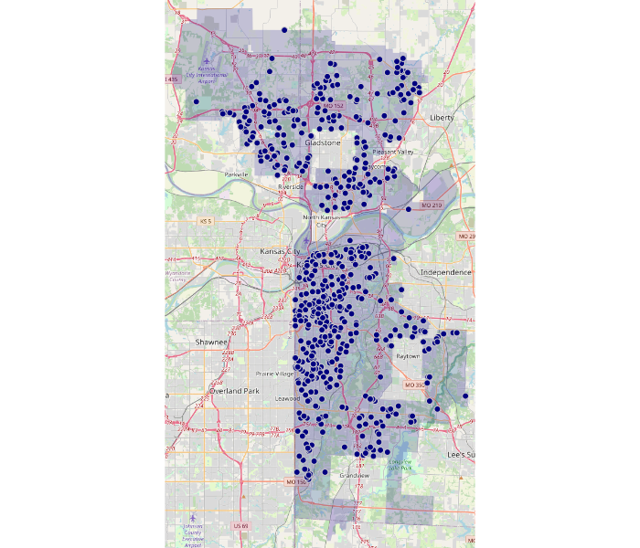

Figure 1: Approximate locations of Mental Health Survey respondents. N = 648.

## Survey sample

The survey was completed by 648 Kansas City residents aged 18 or older. The sample represents all council districts and all Zip Code Tabulation Areas (ZCTAs) that have at least 20% of their area in the city limits and an estimated population of at least 1,100 (Figure 1).[^2] The sample of survey respondents closely reflects the demographics of Kansas City's population in birth sex, collapsed race categories, and Hispanic origin.[^3] The age of the sample skews older than the population, possibly due to nonresponse bias. The sample of individuals who completed surveys is a self-selected subset of the larger group that initially received surveys. Results should be interpreted with this in mind.

Table 1: Survey respondents by council district

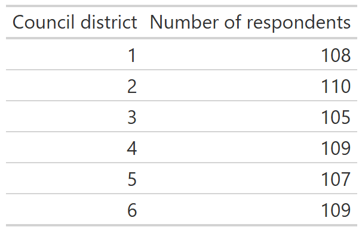

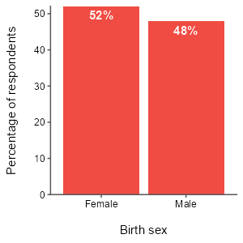

Figure 2: Birth sex of survey sample. N = 647.

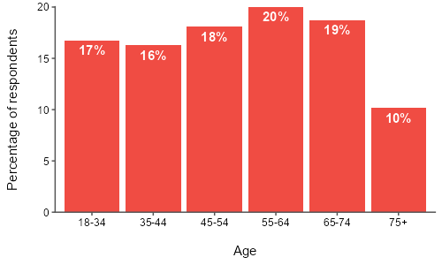

Figure 3: Age of survey sample. N = 609.

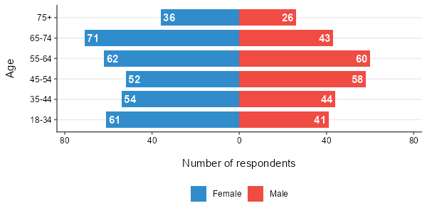

Figure 4: Age structure of survey sample. N = 608.

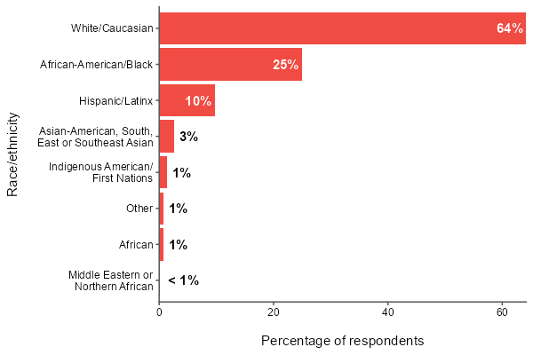

Figure 5: Race/ethnicity of survey sample. Multiple answers were possible. N = 648.

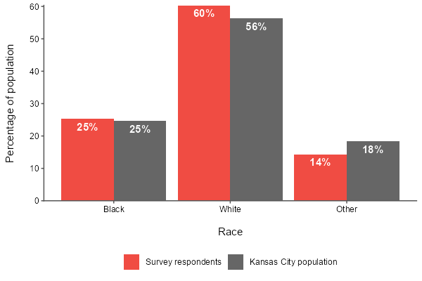

Figure 6: Collapsed race categories of survey sample. “Black” includes anyone who selected only “African-American/Black” or “African”. “White” includes anyone who selected only “Middle Eastern or Northern African” or “White/Caucasian”. “Other” includes anyone who selected another category alone and anyone who selected multiple categories. N = 648.

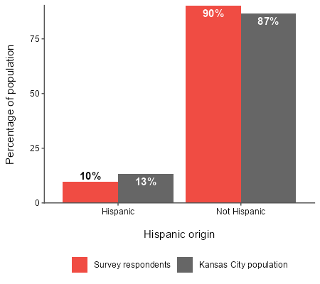

Figure 7: Hispanic origin of survey sample. N = 648.

## Results

### Anxiety and depression

Questions in this section largely concern symptoms of anxiety and depression, and the results provide an overview of residents' recent mental health. They show that many people are dealing with difficult feelings. Respondents revealed that feelings of restlessness, nervousness, and exclusion are common. Thirty-two percent (32%) reported experiencing all symptoms of anxiety and depression in this section with low frequency, while nearly 6% reported experiencing moderate to high frequencies of all symptoms. This shows that most residents have experienced one or more symptoms with at least moderate frequency, and some may be struggling much of the time.[^4]

**During the past 30 days, how often did you feel nervous?**

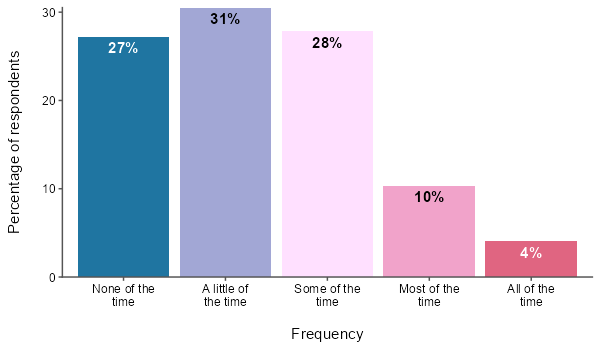

Figure 8: N = 639.

Fourteen percent (14%) of respondents said they feel nervous most or all of the time.

**During the past 30 days, how often did you feel hopeless?**

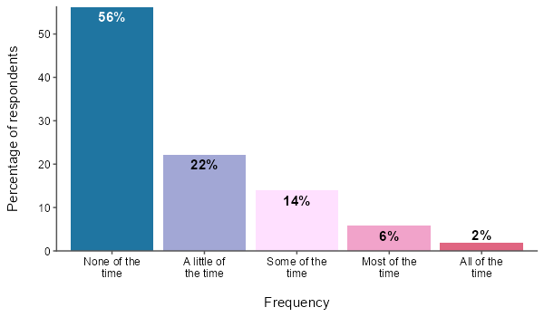

Figure 9: N = 640.

Eight percent (8%) of respondents said they feel hopeless most or all of the time.

**During the past 30 days, how often did you feel restless or fidgety?**

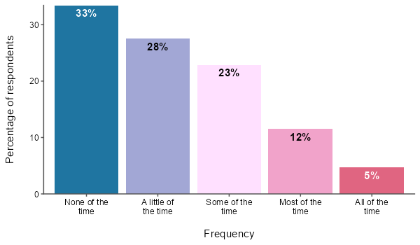

Figure 10: N = 643.

Seventeen percent (17%) of respondents said they feel restless or fidgety most or all of the time.

**During the past 30 days, how often did you feel so depressed that nothing could cheer you up?**

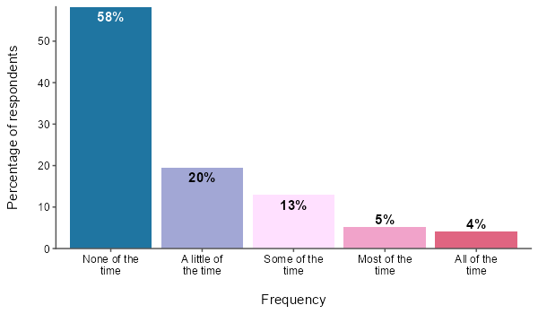

Figure 11: N = 640.

Nine percent (9%) of respondents said they feel so depressed that nothing could cheer them up most or all of the time.

**During the past 30 days, how often did you struggle with daily activities like getting out of bed, showering, and getting dressed?**

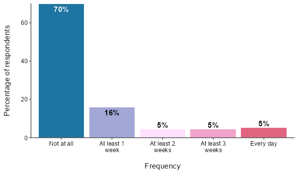

Figure 12: N = 641.

Ten percent (10%) of respondents said they struggle with normal daily activities most or all of the time.

**During the past 30 days, how often did you feel worthless?**

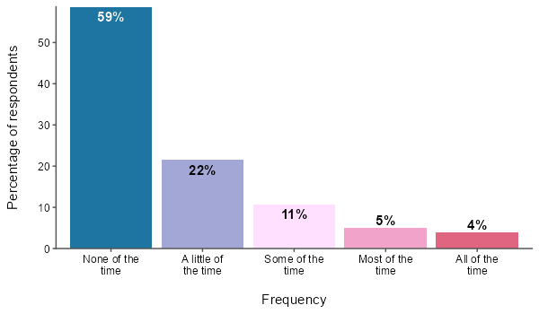

Figure 13: N = 646.

Nine percent (9%) of respondents said they feel worthless most or all of the time.

**How often do you feel left out?**

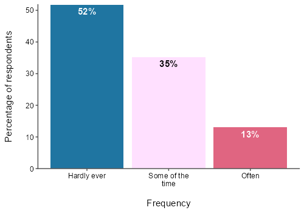

Figure 14: N = 639.

Thirteen percent (13%) of respondents said they often feel left out.

**How would you describe your mental health compared to before the COVID-19 pandemic?**

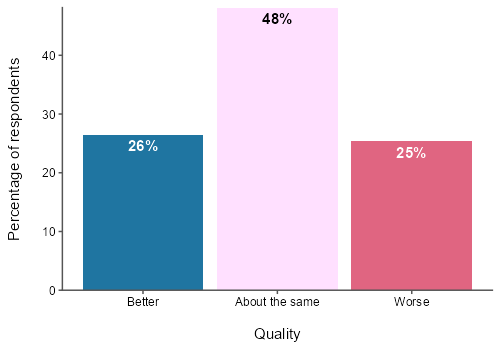

Figure 15: N = 638.

Twenty-five percent (25%) of respondents described their mental health as worse now than it was before the COVID-19 pandemic. About the same amount (26%) described their mental health as better now than before the pandemic.

### Mental health treatment

The benefits of mental health treatment are many, such as teaching skills to manage difficult feelings, providing strategies for coping with stress, and diagnosing conditions that may require further intervention. Unfortunately, responses from the survey show that the mental health care system can be challenging to navigate, especially with the rising demand for services, dwindling workforce, and increasing barriers to care.

Nearly a quarter of respondents reported needing mental health treatment in the past year but not getting it. The top reasons for this were financial: they couldn't afford the cost, didn't have sufficient health insurance, or were unaware of where to find affordable services.

While a growing number of people, particularly young adults, are seeking and receiving mental health treatment, a significant portion of the population with mental illness still goes without. The following results reveal respondents' experiences and perceived barriers surrounding mental health treatment.

**Are you currently taking medicine or receiving treatment from a doctor or other health professional for any type of mental health condition or emotional problem?**

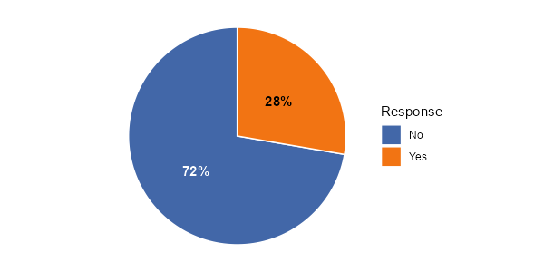

Figure 16: N = 646.

Twenty-eight percent (28%) of respondents said they are currently being treated for a mental health condition.

**During the past 12 months, was there any time when you needed mental health treatment or counseling for yourself but didn’t get it?**

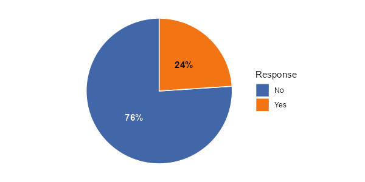

Figure 17: N = 643.

Twenty-four percent (24%) of respondents said they recently needed mental health treatment but didn't get it.

**Was the following a reason why you did not get the mental health treatment or counseling you needed?**

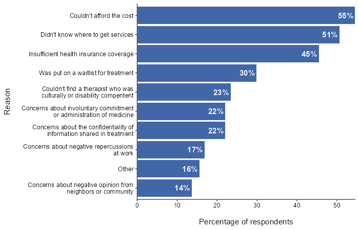

Figure 18: Multiple answers were possible. N = 154.

Among those who recently needed but didn't get mental health treatment, the top three reasons for not getting treatment were 1) they couldn't afford the cost (55%), 2) they didn’t know where to get services (51%), and 3) they didn't have sufficient health insurance coverage (45%).

**Are you aware of agencies within Kansas City where you can receive free mental health services if you are unable to pay?**

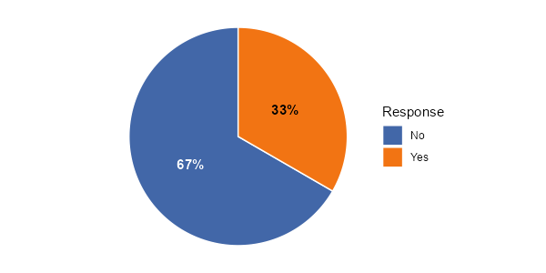

Figure 19: N = 627.

Sixty-seven percent (67%) of respondents said they were unaware of agencies in Kansas City that offer free mental health services for those who are unable to pay.

#### Certified Community Behavioral Health Clinics

Several important but potentially underutilized resources for affordable mental health treatment in Kansas City are the organizations designated as Certified Community Behavioral Health Clinics (CCBHCs). The Substance Abuse and Mental Health Services Administration (SAMHSA), the agency within the US Department of Health and Human Services that supports these organizations, states that

> [CCBHCs] are designed to ensure access to coordinated comprehensive behavioral health care. CCBHCs are required to serve anyone who requests care for mental health or substance use, regardless of their ability to pay, place of residence, or age.[^5]

Nine CCBHC locations where Kansas Citians can access affordable or free mental health treatment are distributed throughout the city. However, two-thirds of survey respondents reported not being aware of such agencies.

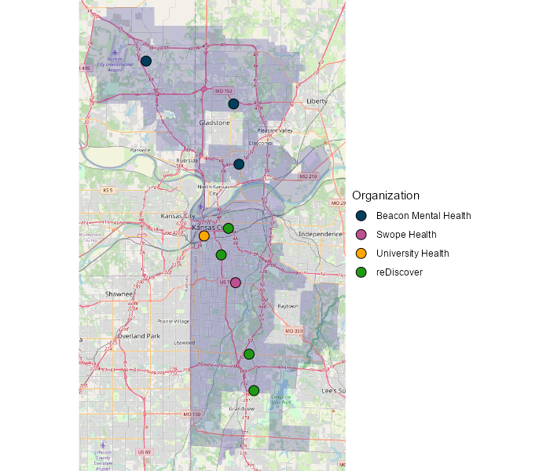

Figure 20: CCBHC locations in Kansas City (as of July 2025).

### Emotional & social loneliness

Extended periods of loneliness can greatly affect a person's thoughts and decision-making. When individuals lack consistent positive social interaction, their ability to think clearly and make sound judgments often diminishes. This can lead to a noticeable decline in overall mental performance, making it more challenging to focus and recall information. These shifts in cognitive function and attention span can, in turn, influence a person's emotions, choices, and how they interact with others. This connection helps explain why loneliness is linked to both a decline in mental sharpness and a decrease in overall physical health.[^6]

Loneliness has been associated with several negative changes in brain function, including

- A reduced ability to think critically and make decisions
- An increased difficulty with daily skills like problem-solving and managing emotions
- An increased tendency toward negative or sad thoughts
- A heightened sense of fear in social situations

Studies indicate that loneliness tends to become more common in early and middle adulthood, often due to a lack of social connections. As individuals transition into middle to later adulthood, they frequently encounter a higher number of significant life changes. These milestones, such as career shifts, significant losses of support networks, retirement, or the loss of physical mobility, can profoundly impact a person's mental health and overall quality of life.[^7]

In this survey, loneliness was measured using a scale that incorporates both emotional loneliness—connectedness to a best friend, romantic partner, or other intimate relationship—and social loneliness—connectedness to an overall network of individuals like their neighbors, extended family, or friend group.

**Emotional loneliness category**

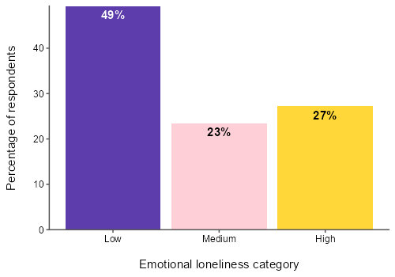

Figure 21: N = 576.

**Social loneliness category**

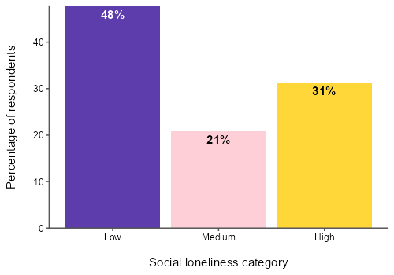

Figure 22: N = 609.

**Total loneliness score**

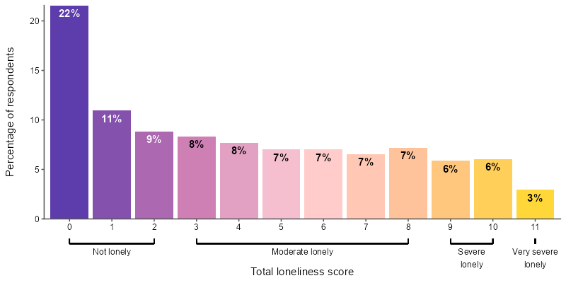

Figure 23: N = 612.

**Total loneliness category**

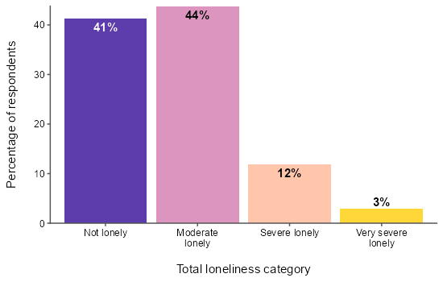

Figure 24: N = 612.

Results from this scale demonstrate that nearly 60% of residents are at least moderately lonely. Most of those are currently experiencing “moderate loneliness”, but a sizeable portion of residents indicated more serious loneliness—15% are either severely lonely or very severely lonely.

### Social media use

Social media's impact on mental health is a complicated and widely debated topic, with research highlighting both harms and benefits from its use. Ultimately, the effect of social media on an individual's mental health depends heavily on how they use it and their own personal vulnerabilities. On the harmful side, excessive social media use is often linked to increased feelings of anxiety, depression, and loneliness.[^8] The constant exposure to carefully edited and often unrealistic portrayals of others' lives can lead to social comparison, creating feelings of inadequacy and low self-esteem. The impact of social media can vary depending on an individual's pre-existing mental health, age, personality, and other life circumstances.

On the other hand, social media can also serve as a valuable tool for social connection, allowing people to stay in touch with family and friends, especially those who are far away. Online communities can provide a sense of belonging and support for individuals with shared interests or experiences, including those dealing with mental health challenges. For some, social media can be a platform for self-expression and creativity, fostering a sense of identity. The following results show respondents' perception of their own social media use.

Considerations for using social media to minimize harmful outcomes:

- Set time limits for social media use and screen time to less than 4 hours per day
- Engage with feeds that are positive or educational
- Prioritize in-person, face-to-face connections

**Social media addiction category**

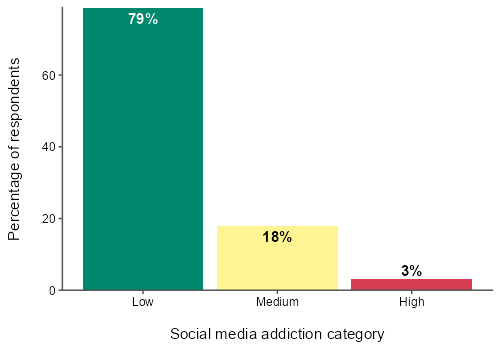

Figure 25: N = 557.

Respondents answered several questions about how their social media use interferes with or has a negative impact on their mental health. From these responses, a composite social media addiction score was calculated. A small minority (3%) experienced high levels of social media addiction, while 18% experienced medium levels of social media addiction, and the majority (79%) experienced low levels of social media addiction. Analysis of the data showed that duration of daily social media use was a predictor of social media addiction score for survey respondents.

**During the past month, how many hours per day did you use social media?**

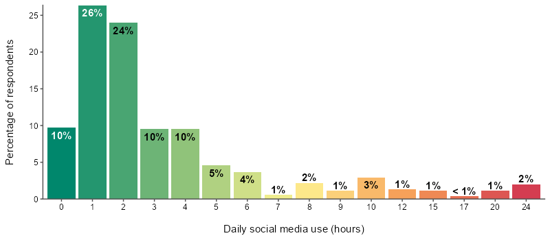

Figure 26: N = 546.

Most respondents (60%) reported daily social media use of 2 hours or less. An additional 20% reported daily social media use of 3-4 hours. Among the remaining 20%, reported use ranged from 5 to 24 hours per day. Because this question allowed respondents to write in their own answers, it isn't possible to know precisely how some individuals were able to use social media 24 hours per day. However, with social media integrated into many aspects of our lives, it can be engaged with actively, via chatting or scrolling through a feed, or passively, via song or video apps playing in the background or apps that track geolocation or biometrics.

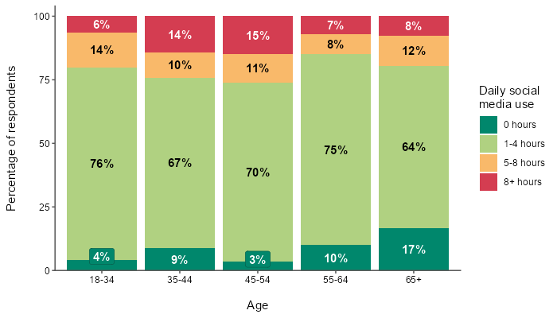

Figure 27: N = 517.

When results are grouped by age, the most intense social media use is seen in ages 45-54 and 35-44.